# Deskriptivní analýza

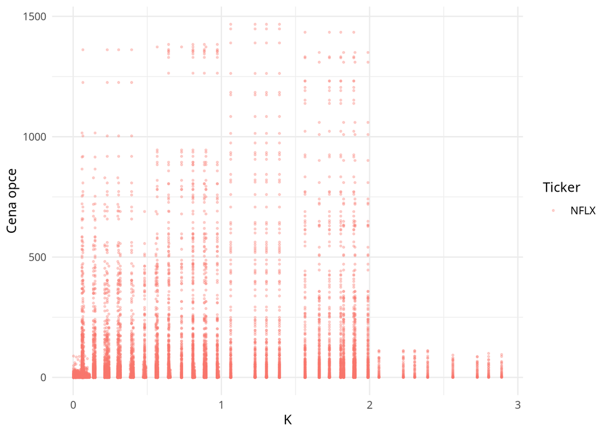

```r
df_moneyness <- df_raw %>% filter(ticker == "NFLX" & call_put == "puts")

ggplot(df_moneyness, aes(x = T, y = true_price, color = ticker)) +
  geom_point(alpha = 0.3, size = 0.5) +
  labs(x = "K", y = "Cena opce",
       color = "Ticker") +
  theme_minimal()
```

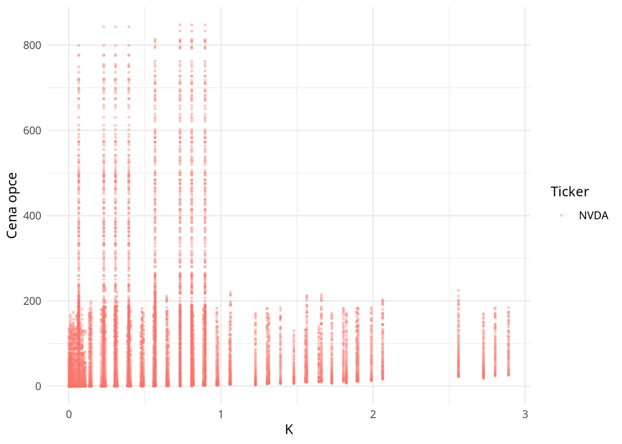

```r
df_moneyness <- df_raw %>% filter(ticker == "NVDA" & call_put == "calls")

ggplot(df_moneyness, aes(x = T, y = true_price, color = ticker)) +
  geom_point(alpha = 0.3, size = 0.5) +
  labs(x = "K", y = "Cena opce",
       color = "Ticker") +
  theme_minimal()
```

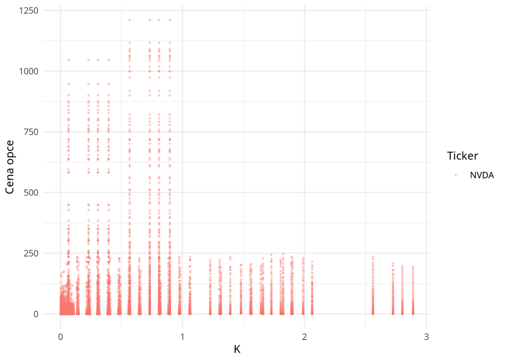

```r
df_moneyness <- df_raw %>% filter(ticker == "NVDA" & call_put == "puts")

ggplot(df_moneyness, aes(x = T, y = true_price, color = ticker)) +
  geom_point(alpha = 0.3, size = 0.5) +
  labs(x = "K", y = "Cena opce",
       color = "Ticker") +
  theme_minimal()
```

Zatímco do určitých hodnot `K` je oceňování vcelku stabilní, od specifických hodnot u NFLX a NVDA dojede k velkému skoku nahoru. Hodnoty se srovánvají s našimi výpočty (tvoří zápornou logaritmickou křivku). Do určitých `K` data vypadají validní, ale nejsem si jistý že můžeme takhle nitpickovat.

Pro NFLX bych pro call opce odstranil hodnoty, pro které je `true_price` větší než 400 a `K` větší než 266. Hodnoty `true_price` větší než 400 jsou nesmyslné a 266 pro `K` je poslední hodnota u které je `true_price` menší než 400 a má `K` menší než 800. Za 266 dochází ke skokovému zvýšení odhadované ceny, což u deep OTM opce nedává vůbec smysl. Pro put opce můžeme odstranit opce s `K` > 266 a opce které pro `K` > 100 mají `true_price` < 10.

Pro NVDA můžeme pro call opce asi celkem bezpečně odstranit hodnoty `true_price` větší než 300 a `K` větší než 500. Pro put opce můžeme odstranit opce které mají pro `K` > 300 `true_price` menší než 100 a opce které mají `K` > 500.

```r
df_more <- df_doctored |>
  mutate(pricing_error = (user_bs - true_price)/S) #|>
  #filter(am_eu == "european" & ticker != "^RUT")
```

```r
query_res <- df_more |> slice_max(pricing_error, n = 50) |> select(ticker, S, K, am_eu, call_put, true_price, sigma, q, T, user_bs, SK_ratio)
print(query_res, n = 50)
```

```
## # A tibble: 50 × 11
##    ticker     S     K am_eu    call_put true_price sigma     q      T user_bs
##    <chr>  <dbl> <dbl> <chr>    <chr>         <dbl> <dbl> <dbl>  <dbl>   <dbl>
##  1 NFLX    84.6   247 american puts          114.  0.338     0 1.81     162.
##  2 NFLX    84.6   207 american puts           74.8 0.338     0 0.885    122.
##  3 NFLX    84.6   202 american puts           70.8 0.338     0 1.30     117.
##  4 NFLX    86.1   247 american puts          114.  0.327     0 1.89     161.
##  5 NFLX    86.1   207 american puts           74.8 0.327     0 0.973    121.
##  6 NFLX    84.6   205 american puts           75.3 0.338     0 0.0603   120.
##  7 NFLX    84.6   195 american puts           65.3 0.338     0 0.0603   110.
##  8 NFLX    84.6   218 american puts           88.3 0.338     0 0.885    133.
##  9 NFLX    84.6   231 american puts          101.  0.338     0 1.30     146.
## 10 NFLX    84.6   218 american puts           88.4 0.338     0 0.808    133.
## 11 NFLX    84.6   170 american puts           40.5 0.338     0 0.307     85.4
## 12 NFLX    84.6   222 american puts           92.5 0.338     0 1.30     137.
```

[output cut: 39 more lines]

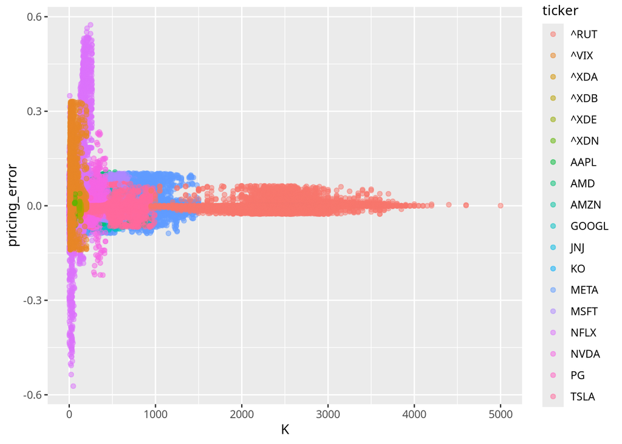

```r
ggplot(df_more, aes(x = K, y = pricing_error, color = ticker)) +
  geom_point(alpha = 0.5)
```

```r
df_more |>
  group_by(ticker) |>
  summarise(
    min    = min(pricing_error, na.rm = TRUE),
    q1     = quantile(pricing_error, 0.25, na.rm = TRUE),
    median = median(pricing_error, na.rm = TRUE),
    q3     = quantile(pricing_error, 0.75, na.rm = TRUE),
    max    = max(pricing_error, na.rm = TRUE)
  )
```

```
## # A tibble: 18 × 6
##    ticker     min       q1    median         q3     max
##    <chr>    <dbl>    <dbl>     <dbl>      <dbl>   <dbl>
##  1 AAPL   -0.0445 -0.00378 -0.000162  0.00583   0.0566
##  2 AMD    -0.0642 -0.00761 -0.000253  0.00878   0.107
##  3 AMZN   -0.0353 -0.0108  -0.00338  -0.000113  0.0263
##  4 GOOGL  -0.0787 -0.0204  -0.00760  -0.000756  0.0483
##  5 JNJ    -0.0361 -0.0112  -0.00387  -0.000640  0.0226
##  6 KO     -0.0450 -0.00754 -0.00236  -0.000274  0.0323
##  7 META   -0.0876 -0.00516 -0.000480  0.00218   0.104
##  8 MSFT   -0.0473 -0.0162  -0.00553  -0.000463  0.103
##  9 NFLX   -0.572  -0.0151  -0.00410  -0.000320  0.574
## 10 NVDA   -0.220  -0.0145  -0.00234  -0.0000464 0.234
## 11 PG     -0.0511 -0.00888 -0.00258  -0.000333  0.0266
## 12 TSLA   -0.0681 -0.00187  0.000768  0.0190    0.0710
## 13 ^RUT   -0.0265 -0.00507 -0.000937  0.000637  0.0631
## 14 ^VIX   -0.140  -0.0102   0.0231    0.121     0.331
## 15 ^XDA   -0.0209 -0.00347  0.00937   0.0275    0.0802
## 16 ^XDB   -0.0484 -0.0232  -0.0158   -0.00853   0.00574
## 17 ^XDE   -0.0328 -0.0103  -0.00289   0.00163   0.0387
## 18 ^XDN   -0.0624 -0.0176  -0.00723  -0.00228   0.0369
```

```r
nrow(df_more |> filter(ticker != "^RUT"))
```

```
## [1] 131259
```

```r
nrow(df_more |> filter(ticker == "^RUT"))
```

```
## [1] 15865
```

# Korelace metod ocenění

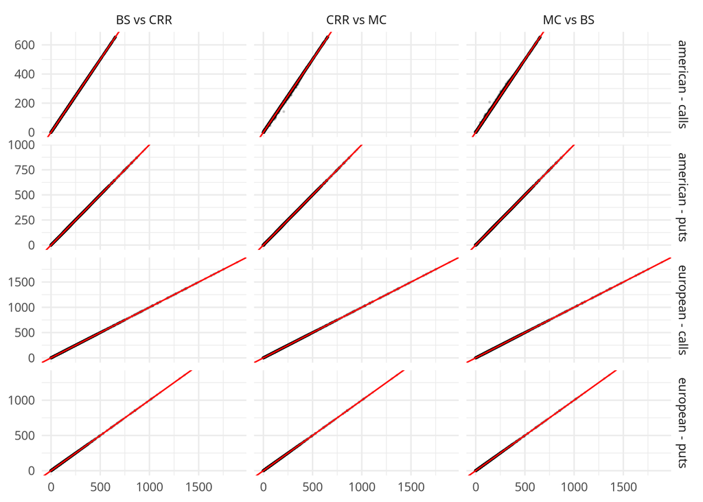

```r
df_corr <- df_doctored %>%
  mutate(type = paste(am_eu, call_put, sep = " - "))

df_pairs <- bind_rows(
  df_corr %>% mutate(comparison = "BS vs CRR", price_x = user_bs,   price_y = user_crr),
  df_corr %>% mutate(comparison = "CRR vs MC", price_x = user_crr,  price_y = user_mc),
  df_corr %>% mutate(comparison = "MC vs BS",  price_x = user_mc,   price_y = user_bs)
)

correlations <- ggplot(df_pairs, aes(x = price_x, y = price_y)) +
  geom_point(alpha = 0.15, size = 0.3) +
  geom_abline(slope = 1, intercept = 0, color = "red", linewidth = 0.5) +
  facet_grid(type ~ comparison, scales = "free") +
  labs(x = NULL, y = NULL) +
  theme_minimal()

ggsave("~/Praxe/bakalarka/figures/correlations.png", correlations, width = 6, height = 4)

correlations
```

```r
df_doctored %>%
  group_by(am_eu, call_put) %>%
  summarise(
    r_BS_CRR = cor(user_bs, user_crr, method = "spearman"),
    r_CRR_MC = cor(user_crr, user_mc, method = "spearman"),
    r_MC_BS  = cor(user_mc, user_bs, method = "spearman"),
    .groups = "drop"
  ) %>%
  kable(digits = 4, booktabs = TRUE)
```

| am_eu | call_put | r_BS_CRR | r_CRR_MC | r_MC_BS |
| --- | --- | --- | --- | --- |
| american | calls | 1.0000 | 0.9989 | 0.9989 |
| american | puts | 0.9997 | 0.9961 | 0.9958 |
| european | calls | 1.0000 | 0.9998 | 0.9998 |
| european | puts | 1.0000 | 0.9978 | 0.9978 |